# AtliQ Hotels Data Analysis Project

## Data Load

### Datasets

We have 5 csv files with records over 1 lac

- dim_date.csv
- dim_hotels.csv
- dim_rooms.csv
- fact_aggregated_bookings.csv
- fact_bookings.csv

## Quick Exploration

|  | booking_id | property_id | booking_date | check_in_date | checkout_date | no_guests | room_category | booking_platform | ratings_given | booking_status | revenue_generated | revenue_realized |
| --- | --- | --- | --- | --- | --- | --- | --- | --- | --- | --- | --- | --- |
| 0 | May012216558RT11 | 16558 | 27-04-22 | 1/5/2022 | 2/5/2022 | -3.0 | RT1 | direct online | 1.0 | Checked Out | 10010 | 10010 |
| 1 | May012216558RT12 | 16558 | 30-04-22 | 1/5/2022 | 2/5/2022 | 2.0 | RT1 | others | NaN | Cancelled | 9100 | 3640 |
| 2 | May012216558RT13 | 16558 | 28-04-22 | 1/5/2022 | 4/5/2022 | 2.0 | RT1 | logtrip | 5.0 | Checked Out | 9100000 | 9100 |
| 3 | May012216558RT14 | 16558 | 28-04-22 | 1/5/2022 | 2/5/2022 | -2.0 | RT1 | others | NaN | Cancelled | 9100 | 3640 |
| 4 | May012216558RT15 | 16558 | 27-04-22 | 1/5/2022 | 2/5/2022 | 4.0 | RT1 | direct online | 5.0 | Checked Out | 10920 | 10920 |

|  | date | mmm yy | week no | day_type |
| --- | --- | --- | --- | --- |
| 0 | 01-May-22 | May 22 | W 19 | weekend |
| 1 | 02-May-22 | May 22 | W 19 | weekeday |
| 2 | 03-May-22 | May 22 | W 19 | weekeday |
| 3 | 04-May-22 | May 22 | W 19 | weekeday |
| 4 | 05-May-22 | May 22 | W 19 | weekeday |

|  | property_id | check_in_date | room_category | successful_bookings | capacity |
| --- | --- | --- | --- | --- | --- |
| 0 | 16559 | 1-May-22 | RT1 | 25 | 30.0 |
| 1 | 19562 | 1-May-22 | RT1 | 28 | 30.0 |
| 2 | 19563 | 1-May-22 | RT1 | 23 | 30.0 |
| 3 | 17558 | 1-May-22 | RT1 | 30 | 19.0 |
| 4 | 16558 | 1-May-22 | RT1 | 18 | 19.0 |

|  | property_id | property_name | category | city |
| --- | --- | --- | --- | --- |
| 0 | 16558 | Atliq Grands | Luxury | Delhi |
| 1 | 16559 | Atliq Exotica | Luxury | Mumbai |
| 2 | 16560 | Atliq City | Business | Delhi |
| 3 | 16561 | Atliq Blu | Luxury | Delhi |
| 4 | 16562 | Atliq Bay | Luxury | Delhi |

|  | room_id | room_class |
| --- | --- | --- |
| 0 | RT1 | Standard |
| 1 | RT2 | Elite |
| 2 | RT3 | Premium |
| 3 | RT4 | Presidential |

## Preparing Data

**We can clearly see that the dates are inconsistent across the dataset.**

|  | booking_id | property_id | booking_date | check_in_date | checkout_date | no_guests | room_category | booking_platform | ratings_given | booking_status | revenue_generated | revenue_realized |
| --- | --- | --- | --- | --- | --- | --- | --- | --- | --- | --- | --- | --- |
| 0 | May012216558RT11 | 16558 | 2022-04-27 00:00:00 | 2022-05-01 00:00:00 | 2022-05-02 00:00:00 | -3.0 | RT1 | direct online | 1.0 | Checked Out | 10010 | 10010 |
| 1 | May012216558RT12 | 16558 | 2022-04-30 00:00:00 | 2022-05-01 00:00:00 | 2022-05-02 00:00:00 | 2.0 | RT1 | others | NaN | Cancelled | 9100 | 3640 |

|  | date | mmm yy | week no | day_type |
| --- | --- | --- | --- | --- |
| 0 | 2022-05-01 | May 22 | W 19 | weekend |
| 1 | 2022-05-02 | May 22 | W 19 | weekeday |

|  | property_id | check_in_date | room_category | successful_bookings | capacity |
| --- | --- | --- | --- | --- | --- |
| 0 | 16559 | 2022-05-01 | RT1 | 25 | 30.0 |
| 1 | 19562 | 2022-05-01 | RT1 | 28 | 30.0 |

```
<class 'pandas.core.frame.DataFrame'>
RangeIndex: 92 entries, 0 to 91
Data columns (total 4 columns):
 #   Column    Non-Null Count  Dtype
---  ------    --------------  -----
 0   date      92 non-null     datetime64[ns]
 1   mmm yy    92 non-null     object
 2   week no   92 non-null     object
 3   day_type  92 non-null     object
dtypes: datetime64[ns](1), object(3)
memory usage: 3.0+ KB
```

```
<class 'pandas.core.frame.DataFrame'>
RangeIndex: 9200 entries, 0 to 9199
Data columns (total 5 columns):
 #   Column               Non-Null Count  Dtype
---  ------               --------------  -----
 0   property_id          9200 non-null   int64
 1   check_in_date        9200 non-null   datetime64[ns]
 2   room_category        9200 non-null   object
 3   successful_bookings  9200 non-null   int64
 4   capacity             9198 non-null   float64
dtypes: datetime64[ns](1), float64(1), int64(2), object(1)
memory usage: 359.5+ KB
```

```
<class 'pandas.core.frame.DataFrame'>
RangeIndex: 134590 entries, 0 to 134589
Data columns (total 12 columns):
 #   Column             Non-Null Count   Dtype
---  ------             --------------   -----
 0   booking_id         134590 non-null  object
 1   property_id        134590 non-null  int64
 2   booking_date       134590 non-null  object
 3   check_in_date      134590 non-null  object
 4   checkout_date      134590 non-null  object
 5   no_guests          134587 non-null  float64
 6   room_category      134590 non-null  object
 7   booking_platform   134590 non-null  object
 8   ratings_given      56683 non-null   float64
 9   booking_status     134590 non-null  object
 10  revenue_generated  134590 non-null  int64
 11  revenue_realized   134590 non-null  int64
dtypes: float64(2), int64(3), object(7)
memory usage: 12.3+ MB
```

**df_bookings date columns are still object dtypes**

```
<class 'pandas.core.frame.DataFrame'>
RangeIndex: 134590 entries, 0 to 134589
Data columns (total 12 columns):
 #   Column             Non-Null Count   Dtype
---  ------             --------------   -----
 0   booking_id         134590 non-null  object
 1   property_id        134590 non-null  int64
 2   booking_date       134590 non-null  datetime64[ns]
 3   check_in_date      134590 non-null  datetime64[ns]
 4   checkout_date      134590 non-null  datetime64[ns]
 5   no_guests          134587 non-null  float64
 6   room_category      134590 non-null  object
 7   booking_platform   134590 non-null  object
 8   ratings_given      56683 non-null   float64
 9   booking_status     134590 non-null  object
 10  revenue_generated  134590 non-null  int64
 11  revenue_realized   134590 non-null  int64
dtypes: datetime64[ns](3), float64(2), int64(3), object(4)
memory usage: 12.3+ MB
```

The datatypes are successfully converted

## Helper functions for Visualization

**Exploring bookings data**

```
(134590, 12)
```

```
array(['RT1', 'RT2', 'RT3', 'RT4'], dtype=object)
```

```
array(['direct online', 'others', 'logtrip', 'tripster', 'makeyourtrip',
       'journey', 'direct offline'], dtype=object)
```

```
booking_platform
others            55066
makeyourtrip      26898
logtrip           14756
direct online     13379
tripster           9630
journey            8106
direct offline     6755
Name: count, dtype: int64
```

### Number of bookings done through booking platforms

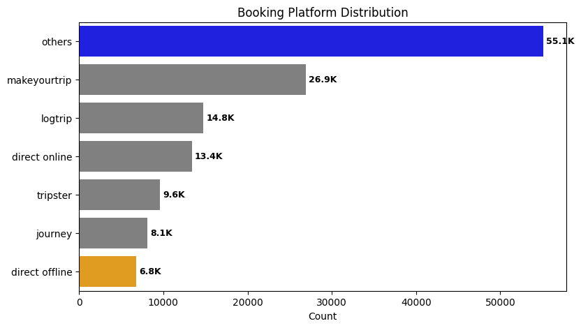

```
count    55066
dtype: int64
```

**Overall Aggregation of Bookings data**

|  | property_id | booking_date | check_in_date | checkout_date | no_guests | ratings_given | revenue_generated | revenue_realized |
| --- | --- | --- | --- | --- | --- | --- | --- | --- |
| count | 134590.000000 | 134590 | 134590 | 134590 | 134587.000000 | 56683.000000 | 1.345900e+05 | 134590.000000 |
| mean | 18061.113493 | 2022-06-11 05:51:49.871461120 | 2022-06-14 22:52:29.939816960 | 2022-06-17 07:51:51.262352640 | 2.036170 | 3.619004 | 1.537805e+04 | 12696.123256 |
| min | 16558.000000 | 2022-04-07 00:00:00 | 2022-05-01 00:00:00 | 2022-05-02 00:00:00 | -17.000000 | 1.000000 | 6.500000e+03 | 2600.000000 |
| 25% | 17558.000000 | 2022-05-19 00:00:00 | 2022-05-23 00:00:00 | 2022-05-25 00:00:00 | 1.000000 | 3.000000 | 9.900000e+03 | 7600.000000 |
| 50% | 17564.000000 | 2022-06-11 00:00:00 | 2022-06-15 00:00:00 | 2022-06-17 00:00:00 | 2.000000 | 4.000000 | 1.350000e+04 | 11700.000000 |
| 75% | 18563.000000 | 2022-07-04 00:00:00 | 2022-07-08 00:00:00 | 2022-07-10 00:00:00 | 2.000000 | 5.000000 | 1.800000e+04 | 15300.000000 |
| max | 19563.000000 | 2022-07-31 00:00:00 | 2022-07-31 00:00:00 | 2022-08-06 00:00:00 | 6.000000 | 5.000000 | 2.856000e+07 | 45220.000000 |
| std | 1093.055847 | NaN | NaN | NaN | 1.034885 | 1.235009 | 9.303604e+04 | 6928.108124 |

**Min and Max Revenue generated**

```
Minimum Revenue: 6500
Maximum Revenue: 28560000
```

**Exploring rest of the files**

```
(25, 4)
```

|  | property_id | property_name | category | city |
| --- | --- | --- | --- | --- |
| 0 | 16558 | Atliq Grands | Luxury | Delhi |
| 1 | 16559 | Atliq Exotica | Luxury | Mumbai |
| 2 | 16560 | Atliq City | Business | Delhi |
| 3 | 16561 | Atliq Blu | Luxury | Delhi |
| 4 | 16562 | Atliq Bay | Luxury | Delhi |

```
category
Luxury      16
Business     9
Name: count, dtype: int64
```

```
city
Delhi        5
Hyderabad    6
Bangalore    6
Mumbai       8
Name: count, dtype: int64
```

### Number of Hotels per City

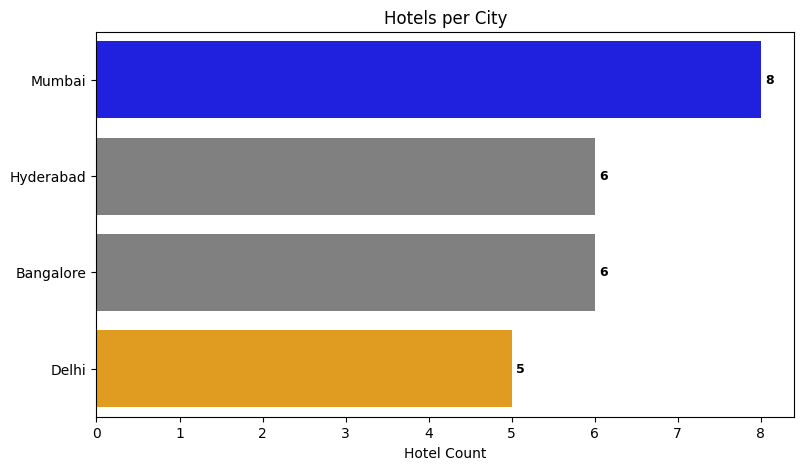

|  | property_id | check_in_date | room_category | successful_bookings | capacity |
| --- | --- | --- | --- | --- | --- |
| 0 | 16559 | 2022-05-01 | RT1 | 25 | 30.0 |
| 1 | 19562 | 2022-05-01 | RT1 | 28 | 30.0 |
| 2 | 19563 | 2022-05-01 | RT1 | 23 | 30.0 |
| 3 | 17558 | 2022-05-01 | RT1 | 30 | 19.0 |
| 4 | 16558 | 2022-05-01 | RT1 | 18 | 19.0 |

```
array([16559, 19562, 19563, 17558, 16558, 17560, 19558, 19560, 17561,
       16560, 16561, 16562, 16563, 17559, 17562, 17563, 18558, 18559,
       18561, 18562, 18563, 19559, 19561, 17564, 18560])
```

**Total Successful Bookings done by each Property**

```
property_id
16558    3153
16559    7338
16560    4693
16561    4418
16562    4820
16563    7211
17558    5053
17559    6142
17560    6013
17561    5183
17562    3424
17563    6337
17564    3982
18558    4475
18559    5256
18560    6638
18561    6458
18562    7333
18563    4737
19558    4400
19559    4729
19560    6079
19561    5736
19562    5812
19563    5413
Name: successful_bookings, dtype: int64
```

**Properties where Successful Bookings crossed the Capacity**

|  | property_id | check_in_date | room_category | successful_bookings | capacity |
| --- | --- | --- | --- | --- | --- |
| 3 | 17558 | 2022-05-01 | RT1 | 30 | 19.0 |
| 12 | 16563 | 2022-05-01 | RT1 | 100 | 41.0 |
| 4136 | 19558 | 2022-06-11 | RT2 | 50 | 39.0 |
| 6209 | 19560 | 2022-07-02 | RT1 | 123 | 26.0 |
| 8522 | 19559 | 2022-07-25 | RT1 | 35 | 24.0 |
| 9194 | 18563 | 2022-07-31 | RT4 | 20 | 18.0 |

**Max Capacity**

|  | property_id | check_in_date | room_category | successful_bookings | capacity |
| --- | --- | --- | --- | --- | --- |
| 27 | 17558 | 2022-05-01 | RT2 | 38 | 50.0 |
| 128 | 17558 | 2022-05-02 | RT2 | 27 | 50.0 |
| 229 | 17558 | 2022-05-03 | RT2 | 26 | 50.0 |
| 328 | 17558 | 2022-05-04 | RT2 | 27 | 50.0 |
| 428 | 17558 | 2022-05-05 | RT2 | 29 | 50.0 |
| ... | ... | ... | ... | ... | ... |
| 8728 | 17558 | 2022-07-27 | RT2 | 22 | 50.0 |
| 8828 | 17558 | 2022-07-28 | RT2 | 21 | 50.0 |
| 8928 | 17558 | 2022-07-29 | RT2 | 23 | 50.0 |
| 9028 | 17558 | 2022-07-30 | RT2 | 32 | 50.0 |
| 9128 | 17558 | 2022-07-31 | RT2 | 30 | 50.0 |

92 rows × 5 columns

## Data Cleaning

|  | date | mmm yy | week no | day_type |
| --- | --- | --- | --- | --- |
| 0 | 2022-05-01 | May 22 | W 19 | weekend |
| 1 | 2022-05-02 | May 22 | W 19 | weekeday |
| 2 | 2022-05-03 | May 22 | W 19 | weekeday |
| 3 | 2022-05-04 | May 22 | W 19 | weekeday |
| 4 | 2022-05-05 | May 22 | W 19 | weekeday |

**We can see that the day_type column values are inconsistent**

|  | date | mmm yy | week no | day_type |
| --- | --- | --- | --- | --- |
| 0 | 2022-05-01 | May 22 | W 19 | weekend |
| 1 | 2022-05-02 | May 22 | W 19 | weekday |
| 2 | 2022-05-03 | May 22 | W 19 | weekday |
| 3 | 2022-05-04 | May 22 | W 19 | weekday |
| 4 | 2022-05-05 | May 22 | W 19 | weekday |

Now it is cleaned

**Cleaning df_bookings**

|  | property_id | booking_date | check_in_date | checkout_date | no_guests | ratings_given | revenue_generated | revenue_realized |
| --- | --- | --- | --- | --- | --- | --- | --- | --- |
| count | 134590.000000 | 134590 | 134590 | 134590 | 134587.000000 | 56683.000000 | 1.345900e+05 | 134590.000000 |
| mean | 18061.113493 | 2022-06-11 05:51:49.871461120 | 2022-06-14 22:52:29.939816960 | 2022-06-17 07:51:51.262352640 | 2.036170 | 3.619004 | 1.537805e+04 | 12696.123256 |
| min | 16558.000000 | 2022-04-07 00:00:00 | 2022-05-01 00:00:00 | 2022-05-02 00:00:00 | -17.000000 | 1.000000 | 6.500000e+03 | 2600.000000 |
| 25% | 17558.000000 | 2022-05-19 00:00:00 | 2022-05-23 00:00:00 | 2022-05-25 00:00:00 | 1.000000 | 3.000000 | 9.900000e+03 | 7600.000000 |
| 50% | 17564.000000 | 2022-06-11 00:00:00 | 2022-06-15 00:00:00 | 2022-06-17 00:00:00 | 2.000000 | 4.000000 | 1.350000e+04 | 11700.000000 |
| 75% | 18563.000000 | 2022-07-04 00:00:00 | 2022-07-08 00:00:00 | 2022-07-10 00:00:00 | 2.000000 | 5.000000 | 1.800000e+04 | 15300.000000 |
| max | 19563.000000 | 2022-07-31 00:00:00 | 2022-07-31 00:00:00 | 2022-08-06 00:00:00 | 6.000000 | 5.000000 | 2.856000e+07 | 45220.000000 |
| std | 1093.055847 | NaN | NaN | NaN | 1.034885 | 1.235009 | 9.303604e+04 | 6928.108124 |

**(1) Cleaning invalid guests**

|  | booking_id | property_id | booking_date | check_in_date | checkout_date | no_guests | room_category | booking_platform | ratings_given | booking_status | revenue_generated | revenue_realized |
| --- | --- | --- | --- | --- | --- | --- | --- | --- | --- | --- | --- | --- |
| 0 | May012216558RT11 | 16558 | 2022-04-27 | 2022-05-01 | 2022-05-02 | -3.0 | RT1 | direct online | 1.0 | Checked Out | 10010 | 10010 |
| 3 | May012216558RT14 | 16558 | 2022-04-28 | 2022-05-01 | 2022-05-02 | -2.0 | RT1 | others | NaN | Cancelled | 9100 | 3640 |
| 17924 | May122218559RT44 | 18559 | 2022-05-12 | 2022-05-12 | 2022-05-14 | -10.0 | RT4 | direct online | NaN | No Show | 20900 | 20900 |
| 18020 | May122218561RT22 | 18561 | 2022-05-08 | 2022-05-12 | 2022-05-14 | -12.0 | RT2 | makeyourtrip | NaN | Cancelled | 9000 | 3600 |
| 18119 | May122218562RT311 | 18562 | 2022-05-05 | 2022-05-12 | 2022-05-17 | -6.0 | RT3 | direct offline | 5.0 | Checked Out | 16800 | 16800 |
| 18121 | May122218562RT313 | 18562 | 2022-05-10 | 2022-05-12 | 2022-05-17 | -4.0 | RT3 | direct online | NaN | Cancelled | 14400 | 5760 |
| 56715 | Jun082218562RT12 | 18562 | 2022-06-05 | 2022-06-08 | 2022-06-13 | -17.0 | RT1 | others | NaN | Checked Out | 6500 | 6500 |
| 119765 | Jul202219560RT220 | 19560 | 2022-07-19 | 2022-07-20 | 2022-07-22 | -1.0 | RT2 | others | NaN | Checked Out | 13500 | 13500 |
| 134586 | Jul312217564RT47 | 17564 | 2022-07-30 | 2022-07-31 | 2022-08-01 | -4.0 | RT4 | logtrip | 2.0 | Checked Out | 38760 | 38760 |

As you can see above, the number of guests having less than zero value represents data error. We can filter these records.

|  | booking_id | property_id | booking_date | check_in_date | checkout_date | no_guests | room_category | booking_platform | ratings_given | booking_status | revenue_generated | revenue_realized |
| --- | --- | --- | --- | --- | --- | --- | --- | --- | --- | --- | --- | --- |
| 1 | May012216558RT12 | 16558 | 2022-04-30 | 2022-05-01 | 2022-05-02 | 2.0 | RT1 | others | NaN | Cancelled | 9100 | 3640 |
| 2 | May012216558RT13 | 16558 | 2022-04-28 | 2022-05-01 | 2022-05-04 | 2.0 | RT1 | logtrip | 5.0 | Checked Out | 9100000 | 9100 |
| 4 | May012216558RT15 | 16558 | 2022-04-27 | 2022-05-01 | 2022-05-02 | 4.0 | RT1 | direct online | 5.0 | Checked Out | 10920 | 10920 |
| 5 | May012216558RT16 | 16558 | 2022-05-01 | 2022-05-01 | 2022-05-03 | 2.0 | RT1 | others | 4.0 | Checked Out | 9100 | 9100 |
| 6 | May012216558RT17 | 16558 | 2022-04-28 | 2022-05-01 | 2022-05-06 | 2.0 | RT1 | others | NaN | Cancelled | 9100 | 3640 |
| ... | ... | ... | ... | ... | ... | ... | ... | ... | ... | ... | ... | ... |
| 134584 | Jul312217564RT45 | 17564 | 2022-07-30 | 2022-07-31 | 2022-08-01 | 2.0 | RT4 | others | 2.0 | Checked Out | 32300 | 32300 |
| 134585 | Jul312217564RT46 | 17564 | 2022-07-29 | 2022-07-31 | 2022-08-03 | 1.0 | RT4 | makeyourtrip | 2.0 | Checked Out | 32300 | 32300 |
| 134587 | Jul312217564RT48 | 17564 | 2022-07-30 | 2022-07-31 | 2022-08-02 | 1.0 | RT4 | tripster | NaN | Cancelled | 32300 | 12920 |
| 134588 | Jul312217564RT49 | 17564 | 2022-07-29 | 2022-07-31 | 2022-08-01 | 2.0 | RT4 | logtrip | 2.0 | Checked Out | 32300 | 32300 |
| 134589 | Jul312217564RT410 | 17564 | 2022-07-31 | 2022-07-31 | 2022-08-01 | 2.0 | RT4 | makeyourtrip | NaN | Cancelled | 32300 | 12920 |

134578 rows × 12 columns

```
(134578, 12)
```

After removing invalid guests:  
Rows : 134578  
Columns : 12

**(2) Outlier removal in revenue generated**

```
Minimum Revenue: 6500
Maximum Revenue: 28560000
```

```
(15378.036937686695, 93040.1549314641)
```

```
294498.50173207896
```

```
-263742.4278567056
```

|  | booking_id | property_id | booking_date | check_in_date | checkout_date | no_guests | room_category | booking_platform | ratings_given | booking_status | revenue_generated | revenue_realized |
| --- | --- | --- | --- | --- | --- | --- | --- | --- | --- | --- | --- | --- |
| 2 | May012216558RT13 | 16558 | 2022-04-28 | 2022-05-01 | 2022-05-04 | 2.0 | RT1 | logtrip | 5.0 | Checked Out | 9100000 | 9100 |
| 111 | May012216559RT32 | 16559 | 2022-04-29 | 2022-05-01 | 2022-05-02 | 6.0 | RT3 | direct online | NaN | Checked Out | 28560000 | 28560 |
| 315 | May012216562RT22 | 16562 | 2022-04-28 | 2022-05-01 | 2022-05-04 | 2.0 | RT2 | direct offline | 3.0 | Checked Out | 12600000 | 12600 |
| 562 | May012217559RT118 | 17559 | 2022-04-26 | 2022-05-01 | 2022-05-02 | 2.0 | RT1 | others | NaN | Cancelled | 2000000 | 4420 |
| 129176 | Jul282216562RT26 | 16562 | 2022-07-21 | 2022-07-28 | 2022-07-29 | 2.0 | RT2 | direct online | 3.0 | Checked Out | 10000000 | 12600 |

The Rows above show revenue values higher than the higher limit. Therefore, they should be removed.

|  | booking_id | property_id | booking_date | check_in_date | checkout_date | no_guests | room_category | booking_platform | ratings_given | booking_status | revenue_generated | revenue_realized |
| --- | --- | --- | --- | --- | --- | --- | --- | --- | --- | --- | --- | --- |
| 1 | May012216558RT12 | 16558 | 2022-04-30 | 2022-05-01 | 2022-05-02 | 2.0 | RT1 | others | NaN | Cancelled | 9100 | 3640 |
| 4 | May012216558RT15 | 16558 | 2022-04-27 | 2022-05-01 | 2022-05-02 | 4.0 | RT1 | direct online | 5.0 | Checked Out | 10920 | 10920 |
| 5 | May012216558RT16 | 16558 | 2022-05-01 | 2022-05-01 | 2022-05-03 | 2.0 | RT1 | others | 4.0 | Checked Out | 9100 | 9100 |
| 6 | May012216558RT17 | 16558 | 2022-04-28 | 2022-05-01 | 2022-05-06 | 2.0 | RT1 | others | NaN | Cancelled | 9100 | 3640 |
| 7 | May012216558RT18 | 16558 | 2022-04-26 | 2022-05-01 | 2022-05-03 | 2.0 | RT1 | logtrip | NaN | No Show | 9100 | 9100 |
| ... | ... | ... | ... | ... | ... | ... | ... | ... | ... | ... | ... | ... |
| 134584 | Jul312217564RT45 | 17564 | 2022-07-30 | 2022-07-31 | 2022-08-01 | 2.0 | RT4 | others | 2.0 | Checked Out | 32300 | 32300 |
| 134585 | Jul312217564RT46 | 17564 | 2022-07-29 | 2022-07-31 | 2022-08-03 | 1.0 | RT4 | makeyourtrip | 2.0 | Checked Out | 32300 | 32300 |
| 134587 | Jul312217564RT48 | 17564 | 2022-07-30 | 2022-07-31 | 2022-08-02 | 1.0 | RT4 | tripster | NaN | Cancelled | 32300 | 12920 |
| 134588 | Jul312217564RT49 | 17564 | 2022-07-29 | 2022-07-31 | 2022-08-01 | 2.0 | RT4 | logtrip | 2.0 | Checked Out | 32300 | 32300 |
| 134589 | Jul312217564RT410 | 17564 | 2022-07-31 | 2022-07-31 | 2022-08-01 | 2.0 | RT4 | makeyourtrip | NaN | Cancelled | 32300 | 12920 |

134573 rows × 12 columns

After removing the rows showing values above higher limit of revenue:  
Rows: 134573  
Columns: 12

```
(134573, 12)
```

**Checking for Revenue realized**

```
count    134573.000000
mean      12695.983585
std        6927.791692
min        2600.000000
25%        7600.000000
50%       11700.000000
75%       15300.000000
max       45220.000000
Name: revenue_realized, dtype: float64
```

```
33479.358661845814
```

|  | booking_id | property_id | booking_date | check_in_date | checkout_date | no_guests | room_category | booking_platform | ratings_given | booking_status | revenue_generated | revenue_realized |
| --- | --- | --- | --- | --- | --- | --- | --- | --- | --- | --- | --- | --- |
| 137 | May012216559RT41 | 16559 | 2022-04-27 | 2022-05-01 | 2022-05-07 | 4.0 | RT4 | others | NaN | Checked Out | 38760 | 38760 |
| 139 | May012216559RT43 | 16559 | 2022-05-01 | 2022-05-01 | 2022-05-02 | 6.0 | RT4 | tripster | 3.0 | Checked Out | 45220 | 45220 |
| 143 | May012216559RT47 | 16559 | 2022-04-28 | 2022-05-01 | 2022-05-03 | 3.0 | RT4 | others | 5.0 | Checked Out | 35530 | 35530 |
| 149 | May012216559RT413 | 16559 | 2022-04-24 | 2022-05-01 | 2022-05-07 | 5.0 | RT4 | logtrip | NaN | Checked Out | 41990 | 41990 |
| 222 | May012216560RT45 | 16560 | 2022-04-30 | 2022-05-01 | 2022-05-03 | 5.0 | RT4 | others | 3.0 | Checked Out | 34580 | 34580 |
| ... | ... | ... | ... | ... | ... | ... | ... | ... | ... | ... | ... | ... |
| 134328 | Jul312219560RT49 | 19560 | 2022-07-31 | 2022-07-31 | 2022-08-02 | 6.0 | RT4 | direct online | 5.0 | Checked Out | 39900 | 39900 |
| 134331 | Jul312219560RT412 | 19560 | 2022-07-31 | 2022-07-31 | 2022-08-01 | 6.0 | RT4 | others | 2.0 | Checked Out | 39900 | 39900 |
| 134467 | Jul312219562RT45 | 19562 | 2022-07-28 | 2022-07-31 | 2022-08-01 | 6.0 | RT4 | makeyourtrip | 4.0 | Checked Out | 39900 | 39900 |
| 134474 | Jul312219562RT412 | 19562 | 2022-07-25 | 2022-07-31 | 2022-08-06 | 5.0 | RT4 | direct offline | 5.0 | Checked Out | 37050 | 37050 |
| 134581 | Jul312217564RT42 | 17564 | 2022-07-31 | 2022-07-31 | 2022-08-01 | 4.0 | RT4 | makeyourtrip | 4.0 | Checked Out | 38760 | 38760 |

1299 rows × 12 columns

One observation we get from the above dataframe is that all rooms are of RT4 category which means a presidential suite. Now, since RT4 is a luxurious room it is likely it's rent will be higher. To make a fair analysis, we need to do data analysis only on RT4 room types

**Checking Revenue realized for RT4 rooms**

|  | room_id | room_class |
| --- | --- | --- |
| 0 | RT1 | Standard |
| 1 | RT2 | Elite |
| 2 | RT3 | Premium |
| 3 | RT4 | Presidential |

```
count    16071.000000
mean     23439.308444
std       9048.599076
min       7600.000000
25%      19000.000000
50%      26600.000000
75%      32300.000000
max      45220.000000
Name: revenue_realized, dtype: float64
```

```
50583
```

Here, the higher limit comes to be 50583 and in our dataframe above we can see that the max value for the revenue realized is 45220. Hence, we can conclude that there are no outliers in the room_category column and therefore, we don't need to do any data cleaning on it.

**Checking for null values**

```
booking_id               0
property_id              0
booking_date             0
check_in_date            0
checkout_date            0
no_guests                0
room_category            0
booking_platform         0
ratings_given        77897
booking_status           0
revenue_generated        0
revenue_realized         0
dtype: int64
```

**Cleaning df_agg_bookings**

|  | property_id | check_in_date | room_category | successful_bookings | capacity |
| --- | --- | --- | --- | --- | --- |
| 0 | 16559 | 2022-05-01 | RT1 | 25 | 30.0 |
| 1 | 19562 | 2022-05-01 | RT1 | 28 | 30.0 |
| 2 | 19563 | 2022-05-01 | RT1 | 23 | 30.0 |
| 3 | 17558 | 2022-05-01 | RT1 | 30 | 19.0 |
| 4 | 16558 | 2022-05-01 | RT1 | 18 | 19.0 |

**Checking for null values**

```
property_id            0
check_in_date          0
room_category          0
successful_bookings    0
capacity               2
dtype: int64
```

|  | property_id | check_in_date | room_category | successful_bookings | capacity |
| --- | --- | --- | --- | --- | --- |
| 8 | 17561 | 2022-05-01 | RT1 | 22 | NaN |
| 14 | 17562 | 2022-05-01 | RT1 | 12 | NaN |

**Filling the null values with median values**

```
25.0
```

|  | property_id | check_in_date | room_category | successful_bookings | capacity |
| --- | --- | --- | --- | --- | --- |
| 8 | 17561 | 2022-05-01 | RT1 | 22 | 25.0 |
| 14 | 17562 | 2022-05-01 | RT1 | 12 | 25.0 |

**Properties where successful bookings are more than capacity. That is an outlier**

|  | property_id | check_in_date | room_category | successful_bookings | capacity |
| --- | --- | --- | --- | --- | --- |
| 3 | 17558 | 2022-05-01 | RT1 | 30 | 19.0 |
| 12 | 16563 | 2022-05-01 | RT1 | 100 | 41.0 |
| 4136 | 19558 | 2022-06-11 | RT2 | 50 | 39.0 |
| 6209 | 19560 | 2022-07-02 | RT1 | 123 | 26.0 |
| 8522 | 19559 | 2022-07-25 | RT1 | 35 | 24.0 |
| 9194 | 18563 | 2022-07-31 | RT4 | 20 | 18.0 |

```
(9200, 5)
```

```
(9194, 5)
```

Rows after cleaning: 9194  
Columns after cleaning: 5

## Data Transformation

|  | property_id | check_in_date | room_category | successful_bookings | capacity |
| --- | --- | --- | --- | --- | --- |
| 0 | 16559 | 2022-05-01 | RT1 | 25 | 30.0 |
| 1 | 19562 | 2022-05-01 | RT1 | 28 | 30.0 |
| 2 | 19563 | 2022-05-01 | RT1 | 23 | 30.0 |
| 4 | 16558 | 2022-05-01 | RT1 | 18 | 19.0 |
| 5 | 17560 | 2022-05-01 | RT1 | 28 | 40.0 |

**Create occupancy percentage column**

|  | property_id | check_in_date | room_category | successful_bookings | capacity | occ_pct |
| --- | --- | --- | --- | --- | --- | --- |
| 0 | 16559 | 2022-05-01 | RT1 | 25 | 30.0 | 0.833333 |
| 1 | 19562 | 2022-05-01 | RT1 | 28 | 30.0 | 0.933333 |
| 2 | 19563 | 2022-05-01 | RT1 | 23 | 30.0 | 0.766667 |
| 4 | 16558 | 2022-05-01 | RT1 | 18 | 19.0 | 0.947368 |
| 5 | 17560 | 2022-05-01 | RT1 | 28 | 40.0 | 0.700000 |

**Converting values to percentage format**

|  | property_id | check_in_date | room_category | successful_bookings | capacity | occ_pct |
| --- | --- | --- | --- | --- | --- | --- |
| 0 | 16559 | 2022-05-01 | RT1 | 25 | 30.0 | 83.33 |
| 1 | 19562 | 2022-05-01 | RT1 | 28 | 30.0 | 93.33 |
| 2 | 19563 | 2022-05-01 | RT1 | 23 | 30.0 | 76.67 |
| 4 | 16558 | 2022-05-01 | RT1 | 18 | 19.0 | 94.74 |
| 5 | 17560 | 2022-05-01 | RT1 | 28 | 40.0 | 70.00 |

```
<class 'pandas.core.frame.DataFrame'>
Index: 9194 entries, 0 to 9199
Data columns (total 6 columns):
 #   Column               Non-Null Count  Dtype
---  ------               --------------  -----
 0   property_id          9194 non-null   int64
 1   check_in_date        9194 non-null   datetime64[ns]
 2   room_category        9194 non-null   object
 3   successful_bookings  9194 non-null   int64
 4   capacity             9194 non-null   float64
 5   occ_pct              9194 non-null   float64
dtypes: datetime64[ns](1), float64(2), int64(2), object(1)
memory usage: 502.8+ KB
```

Column is successfully created.

## Insights Generation

**1. What is the average occupancy rate in each of the room categories?**

```
room_category
RT1    57.89
RT2    58.01
RT3    58.03
RT4    59.28
Name: occ_pct, dtype: float64
```

Manager may say, "I don't understand RT1, RT2".  
Therefore:  
Printing room categories such as Standard, Premium, Elite etc along with average occupancy percentage would be better

|  | room_id | room_class |
| --- | --- | --- |
| 0 | RT1 | Standard |
| 1 | RT2 | Elite |
| 2 | RT3 | Premium |
| 3 | RT4 | Presidential |

**Merging df_agg_bookings and df_rooms**

New datframe: df

|  | property_id | check_in_date | room_category | successful_bookings | capacity | occ_pct | room_id | room_class |
| --- | --- | --- | --- | --- | --- | --- | --- | --- |
| 0 | 16559 | 2022-05-01 | RT1 | 25 | 30.0 | 83.33 | RT1 | Standard |
| 1 | 19562 | 2022-05-01 | RT1 | 28 | 30.0 | 93.33 | RT1 | Standard |
| 2 | 19563 | 2022-05-01 | RT1 | 23 | 30.0 | 76.67 | RT1 | Standard |
| 3 | 16558 | 2022-05-01 | RT1 | 18 | 19.0 | 94.74 | RT1 | Standard |
| 4 | 17560 | 2022-05-01 | RT1 | 28 | 40.0 | 70.00 | RT1 | Standard |

**Dropping room_id which is already in df_agg_bookings by name room_category**

|  | property_id | check_in_date | room_category | successful_bookings | capacity | occ_pct | room_class |
| --- | --- | --- | --- | --- | --- | --- | --- |
| 0 | 16559 | 2022-05-01 | RT1 | 25 | 30.0 | 83.33 | Standard |
| 1 | 19562 | 2022-05-01 | RT1 | 28 | 30.0 | 93.33 | Standard |
| 2 | 19563 | 2022-05-01 | RT1 | 23 | 30.0 | 76.67 | Standard |
| 3 | 16558 | 2022-05-01 | RT1 | 18 | 19.0 | 94.74 | Standard |
| 4 | 17560 | 2022-05-01 | RT1 | 28 | 40.0 | 70.00 | Standard |

**Average Occupancy % by Room Class**

```
room_class
Elite           58.01
Premium         58.03
Presidential    59.28
Standard        57.89
Name: occ_pct, dtype: float64
```

**2. Average occupancy rate per city.**

|  | property_id | property_name | category | city |
| --- | --- | --- | --- | --- |
| 0 | 16558 | Atliq Grands | Luxury | Delhi |
| 1 | 16559 | Atliq Exotica | Luxury | Mumbai |
| 2 | 16560 | Atliq City | Business | Delhi |
| 3 | 16561 | Atliq Blu | Luxury | Delhi |
| 4 | 16562 | Atliq Bay | Luxury | Delhi |

**Merging df and df_hotels**

df already has df_agg_bookings data and df_rooms data before this

|  | property_id | check_in_date | room_category | successful_bookings | capacity | occ_pct | room_class | property_name | category | city |
| --- | --- | --- | --- | --- | --- | --- | --- | --- | --- | --- |
| 0 | 16559 | 2022-05-01 | RT1 | 25 | 30.0 | 83.33 | Standard | Atliq Exotica | Luxury | Mumbai |
| 1 | 19562 | 2022-05-01 | RT1 | 28 | 30.0 | 93.33 | Standard | Atliq Bay | Luxury | Bangalore |
| 2 | 19563 | 2022-05-01 | RT1 | 23 | 30.0 | 76.67 | Standard | Atliq Palace | Business | Bangalore |
| 3 | 16558 | 2022-05-01 | RT1 | 18 | 19.0 | 94.74 | Standard | Atliq Grands | Luxury | Delhi |
| 4 | 17560 | 2022-05-01 | RT1 | 28 | 40.0 | 70.00 | Standard | Atliq City | Business | Mumbai |

### Average Occupancy Rate by City

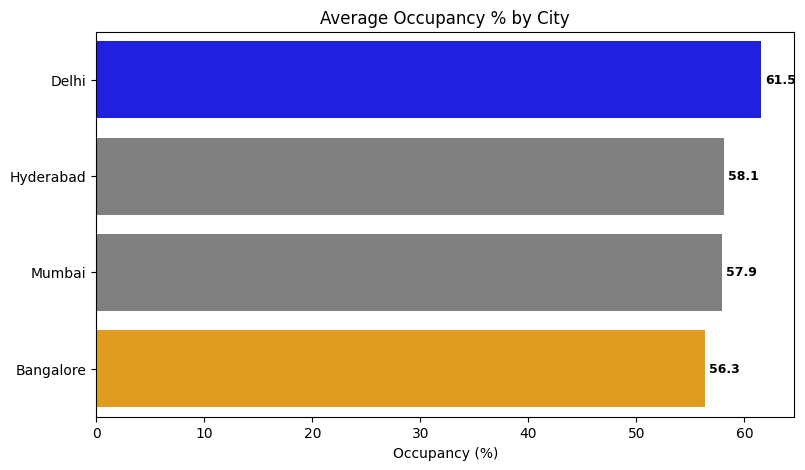

**3. When was the occupancy better? Weekday or Weekend?**

|  | date | mmm yy | week no | day_type |
| --- | --- | --- | --- | --- |
| 0 | 2022-05-01 | May 22 | W 19 | weekend |
| 1 | 2022-05-02 | May 22 | W 19 | weekday |
| 2 | 2022-05-03 | May 22 | W 19 | weekday |
| 3 | 2022-05-04 | May 22 | W 19 | weekday |
| 4 | 2022-05-05 | May 22 | W 19 | weekday |

**Merging df and df_date**

|  | property_id | check_in_date | room_category | successful_bookings | capacity | occ_pct | room_class | property_name | category | city | date | mmm yy | week no | day_type |
| --- | --- | --- | --- | --- | --- | --- | --- | --- | --- | --- | --- | --- | --- | --- |
| 0 | 16559 | 2022-05-01 | RT1 | 25 | 30.0 | 83.33 | Standard | Atliq Exotica | Luxury | Mumbai | 2022-05-01 | May 22 | W 19 | weekend |
| 1 | 19562 | 2022-05-01 | RT1 | 28 | 30.0 | 93.33 | Standard | Atliq Bay | Luxury | Bangalore | 2022-05-01 | May 22 | W 19 | weekend |
| 2 | 19563 | 2022-05-01 | RT1 | 23 | 30.0 | 76.67 | Standard | Atliq Palace | Business | Bangalore | 2022-05-01 | May 22 | W 19 | weekend |
| 3 | 16558 | 2022-05-01 | RT1 | 18 | 19.0 | 94.74 | Standard | Atliq Grands | Luxury | Delhi | 2022-05-01 | May 22 | W 19 | weekend |
| 4 | 17560 | 2022-05-01 | RT1 | 28 | 40.0 | 70.00 | Standard | Atliq City | Business | Mumbai | 2022-05-01 | May 22 | W 19 | weekend |

**Occupancy %- Weekday vs Weekend**

```
day_type
weekday    51.81
weekend    73.96
Name: occ_pct, dtype: float64
```

**4. Monthly Trend by Occupancy**

```
mmm yy
May 22    58.93
Jun 22    58.03
Jul 22    57.94
Name: occ_pct, dtype: float64
```

### Monthly Trend by Occupancy

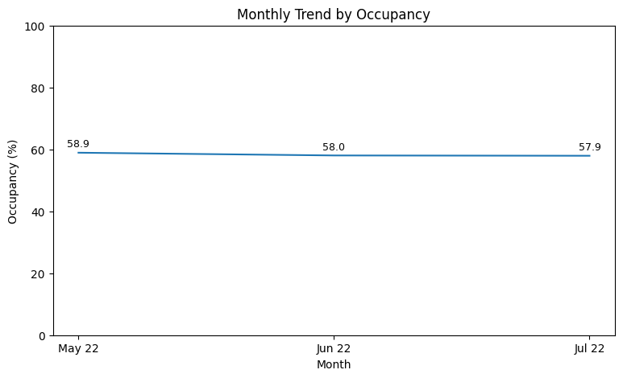

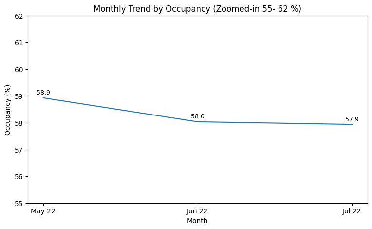

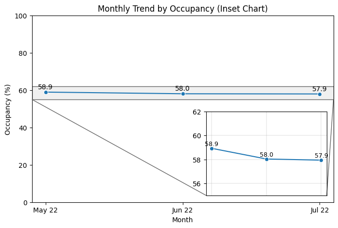

**In the month of June, what is the occupancy for different cities?**

```
array(['May 22', 'Jun 22', 'Jul 22'], dtype=object)
```

|  | property_id | check_in_date | room_category | successful_bookings | capacity | occ_pct | room_class | property_name | category | city | date | mmm yy | week no | day_type |
| --- | --- | --- | --- | --- | --- | --- | --- | --- | --- | --- | --- | --- | --- | --- |
| 3098 | 16559 | 2022-06-01 | RT1 | 14 | 30.0 | 46.67 | Standard | Atliq Exotica | Luxury | Mumbai | 2022-06-01 | Jun 22 | W 23 | weekday |
| 3099 | 18560 | 2022-06-01 | RT1 | 18 | 30.0 | 60.00 | Standard | Atliq City | Business | Hyderabad | 2022-06-01 | Jun 22 | W 23 | weekday |
| 3100 | 19562 | 2022-06-01 | RT1 | 18 | 30.0 | 60.00 | Standard | Atliq Bay | Luxury | Bangalore | 2022-06-01 | Jun 22 | W 23 | weekday |
| 3101 | 19563 | 2022-06-01 | RT1 | 14 | 30.0 | 46.67 | Standard | Atliq Palace | Business | Bangalore | 2022-06-01 | Jun 22 | W 23 | weekday |
| 3102 | 17558 | 2022-06-01 | RT1 | 8 | 19.0 | 42.11 | Standard | Atliq Grands | Luxury | Mumbai | 2022-06-01 | Jun 22 | W 23 | weekday |

**Average Occupancy % by City in June**

```
city
Delhi        61.46
Mumbai       57.79
Hyderabad    57.69
Bangalore    55.85
Name: occ_pct, dtype: float64
```

**Reading and Exploring new data**

|  | property_id | property_name | category | city | room_category | room_class | check_in_date | mmm yy | week no | day_type | successful_bookings | capacity | occ% |
| --- | --- | --- | --- | --- | --- | --- | --- | --- | --- | --- | --- | --- | --- |
| 0 | 16559 | Atliq Exotica | Luxury | Mumbai | RT1 | Standard | 2022-08-01 | Aug-22 | W 32 | weekeday | 30 | 30 | 100.00 |
| 1 | 19562 | Atliq Bay | Luxury | Bangalore | RT1 | Standard | 2022-08-01 | Aug-22 | W 32 | weekeday | 21 | 30 | 70.00 |
| 2 | 19563 | Atliq Palace | Business | Bangalore | RT1 | Standard | 2022-08-01 | Aug-22 | W 32 | weekeday | 23 | 30 | 76.67 |
| 3 | 19558 | Atliq Grands | Luxury | Bangalore | RT1 | Standard | 2022-08-01 | Aug-22 | W 32 | weekeday | 30 | 40 | 75.00 |
| 4 | 19560 | Atliq City | Business | Bangalore | RT1 | Standard | 2022-08-01 | Aug-22 | W 32 | weekeday | 20 | 26 | 76.92 |

**Cleaning the day_type column**

|  | property_id | property_name | category | city | room_category | room_class | check_in_date | mmm yy | week no | day_type | successful_bookings | capacity | occ% |
| --- | --- | --- | --- | --- | --- | --- | --- | --- | --- | --- | --- | --- | --- |
| 0 | 16559 | Atliq Exotica | Luxury | Mumbai | RT1 | Standard | 2022-08-01 | Aug-22 | W 32 | weekday | 30 | 30 | 100.0 |
| 1 | 19562 | Atliq Bay | Luxury | Bangalore | RT1 | Standard | 2022-08-01 | Aug-22 | W 32 | weekday | 21 | 30 | 70.0 |

```
Index(['property_id', 'property_name', 'category', 'city', 'room_category',
       'room_class', 'check_in_date', 'mmm yy', 'week no', 'day_type',
       'successful_bookings', 'capacity', 'occ%'],
      dtype='object')
```

```
Index(['property_id', 'check_in_date', 'room_category', 'successful_bookings',
       'capacity', 'occ_pct', 'room_class', 'property_name', 'category',
       'city', 'date', 'mmm yy', 'week no', 'day_type'],
      dtype='object')
```

```
(7, 13)
```

Columns in august data: 13

```
(9194, 14)
```

Columns in the dataframe where the august data is to be appended: 14

Number of Columns should be same

**Dropping the extra date column created due to merge operation**

|  | property_id | check_in_date | room_category | successful_bookings | capacity | occ_pct | room_class | property_name | category | city | mmm yy | week no | day_type |
| --- | --- | --- | --- | --- | --- | --- | --- | --- | --- | --- | --- | --- | --- |
| 0 | 16559 | 2022-05-01 | RT1 | 25 | 30.0 | 83.33 | Standard | Atliq Exotica | Luxury | Mumbai | May 22 | W 19 | weekend |
| 1 | 19562 | 2022-05-01 | RT1 | 28 | 30.0 | 93.33 | Standard | Atliq Bay | Luxury | Bangalore | May 22 | W 19 | weekend |
| 2 | 19563 | 2022-05-01 | RT1 | 23 | 30.0 | 76.67 | Standard | Atliq Palace | Business | Bangalore | May 22 | W 19 | weekend |
| 3 | 16558 | 2022-05-01 | RT1 | 18 | 19.0 | 94.74 | Standard | Atliq Grands | Luxury | Delhi | May 22 | W 19 | weekend |
| 4 | 17560 | 2022-05-01 | RT1 | 28 | 40.0 | 70.00 | Standard | Atliq City | Business | Mumbai | May 22 | W 19 | weekend |

```
(9194, 13)
```

**Updating the records**

|  | property_id | check_in_date | room_category | successful_bookings | capacity | occ_pct | room_class | property_name | category | city | mmm yy | week no | day_type | occ% |
| --- | --- | --- | --- | --- | --- | --- | --- | --- | --- | --- | --- | --- | --- | --- |
| 9196 | 19563 | 2022-08-01 | RT1 | 23 | 30.0 | NaN | Standard | Atliq Palace | Business | Bangalore | Aug-22 | W 32 | weekday | 76.67 |
| 9197 | 19558 | 2022-08-01 | RT1 | 30 | 40.0 | NaN | Standard | Atliq Grands | Luxury | Bangalore | Aug-22 | W 32 | weekday | 75.00 |
| 9198 | 19560 | 2022-08-01 | RT1 | 20 | 26.0 | NaN | Standard | Atliq City | Business | Bangalore | Aug-22 | W 32 | weekday | 76.92 |
| 9199 | 17561 | 2022-08-01 | RT1 | 18 | 26.0 | NaN | Standard | Atliq Blu | Luxury | Mumbai | Aug-22 | W 32 | weekday | 69.23 |
| 9200 | 17564 | 2022-08-01 | RT1 | 10 | 16.0 | NaN | Standard | Atliq Seasons | Business | Mumbai | Aug-22 | W 32 | weekday | 62.50 |

**5. Revenue realized per city**

|  | booking_id | property_id | booking_date | check_in_date | checkout_date | no_guests | room_category | booking_platform | ratings_given | booking_status | revenue_generated | revenue_realized |
| --- | --- | --- | --- | --- | --- | --- | --- | --- | --- | --- | --- | --- |
| 1 | May012216558RT12 | 16558 | 2022-04-30 | 2022-05-01 | 2022-05-02 | 2.0 | RT1 | others | NaN | Cancelled | 9100 | 3640 |
| 4 | May012216558RT15 | 16558 | 2022-04-27 | 2022-05-01 | 2022-05-02 | 4.0 | RT1 | direct online | 5.0 | Checked Out | 10920 | 10920 |
| 5 | May012216558RT16 | 16558 | 2022-05-01 | 2022-05-01 | 2022-05-03 | 2.0 | RT1 | others | 4.0 | Checked Out | 9100 | 9100 |

|  | property_id | property_name | category | city |
| --- | --- | --- | --- | --- |
| 0 | 16558 | Atliq Grands | Luxury | Delhi |
| 1 | 16559 | Atliq Exotica | Luxury | Mumbai |
| 2 | 16560 | Atliq City | Business | Delhi |

**Merging df_bookings and df_hotels**

|  | booking_id | property_id | booking_date | check_in_date | checkout_date | no_guests | room_category | booking_platform | ratings_given | booking_status | revenue_generated | revenue_realized | property_name | category | city |
| --- | --- | --- | --- | --- | --- | --- | --- | --- | --- | --- | --- | --- | --- | --- | --- |
| 0 | May012216558RT12 | 16558 | 2022-04-30 | 2022-05-01 | 2022-05-02 | 2.0 | RT1 | others | NaN | Cancelled | 9100 | 3640 | Atliq Grands | Luxury | Delhi |
| 1 | May012216558RT15 | 16558 | 2022-04-27 | 2022-05-01 | 2022-05-02 | 4.0 | RT1 | direct online | 5.0 | Checked Out | 10920 | 10920 | Atliq Grands | Luxury | Delhi |
| 2 | May012216558RT16 | 16558 | 2022-05-01 | 2022-05-01 | 2022-05-03 | 2.0 | RT1 | others | 4.0 | Checked Out | 9100 | 9100 | Atliq Grands | Luxury | Delhi |

```
city
Bangalore    420383550
Delhi        294404488
Hyderabad    325179310
Mumbai       668569251
Name: revenue_realized, dtype: int64
```

### Revenue realized by City

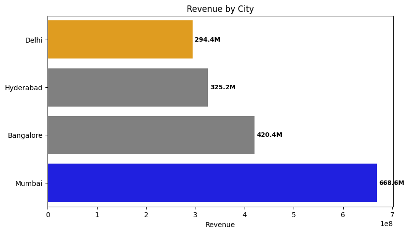

**6. Month by month revenue**

```
array(['May 22', 'Jun 22', 'Jul 22'], dtype=object)
```

|  | date | mmm yy | week no | day_type |
| --- | --- | --- | --- | --- |
| 0 | 2022-05-01 | May 22 | W 19 | weekend |
| 1 | 2022-05-02 | May 22 | W 19 | weekday |

**Merging df_bookings_all and df_date**

|  | booking_id | property_id | booking_date | check_in_date | checkout_date | no_guests | room_category | booking_platform | ratings_given | booking_status | revenue_generated | revenue_realized | property_name | category | city | date | mmm yy | week no | day_type |
| --- | --- | --- | --- | --- | --- | --- | --- | --- | --- | --- | --- | --- | --- | --- | --- | --- | --- | --- | --- |
| 0 | May012216558RT12 | 16558 | 2022-04-30 | 2022-05-01 | 2022-05-02 | 2.0 | RT1 | others | NaN | Cancelled | 9100 | 3640 | Atliq Grands | Luxury | Delhi | 2022-05-01 | May 22 | W 19 | weekend |
| 1 | May012216558RT15 | 16558 | 2022-04-27 | 2022-05-01 | 2022-05-02 | 4.0 | RT1 | direct online | 5.0 | Checked Out | 10920 | 10920 | Atliq Grands | Luxury | Delhi | 2022-05-01 | May 22 | W 19 | weekend |
| 2 | May012216558RT16 | 16558 | 2022-05-01 | 2022-05-01 | 2022-05-03 | 2.0 | RT1 | others | 4.0 | Checked Out | 9100 | 9100 | Atliq Grands | Luxury | Delhi | 2022-05-01 | May 22 | W 19 | weekend |

|  | booking_id | property_id | booking_date | check_in_date | checkout_date | no_guests | room_category | booking_platform | ratings_given | booking_status | revenue_generated | revenue_realized | property_name | category | city | mmm yy | week no | day_type |
| --- | --- | --- | --- | --- | --- | --- | --- | --- | --- | --- | --- | --- | --- | --- | --- | --- | --- | --- |
| 0 | May012216558RT12 | 16558 | 2022-04-30 | 2022-05-01 | 2022-05-02 | 2.0 | RT1 | others | NaN | Cancelled | 9100 | 3640 | Atliq Grands | Luxury | Delhi | May 22 | W 19 | weekend |
| 1 | May012216558RT15 | 16558 | 2022-04-27 | 2022-05-01 | 2022-05-02 | 4.0 | RT1 | direct online | 5.0 | Checked Out | 10920 | 10920 | Atliq Grands | Luxury | Delhi | May 22 | W 19 | weekend |
| 2 | May012216558RT16 | 16558 | 2022-05-01 | 2022-05-01 | 2022-05-03 | 2.0 | RT1 | others | 4.0 | Checked Out | 9100 | 9100 | Atliq Grands | Luxury | Delhi | May 22 | W 19 | weekend |

```
mmm yy
Jul 22    572843348
Jun 22    553925855
May 22    581767396
Name: revenue_realized, dtype: int64
```

### Monthly Trend by Revenue

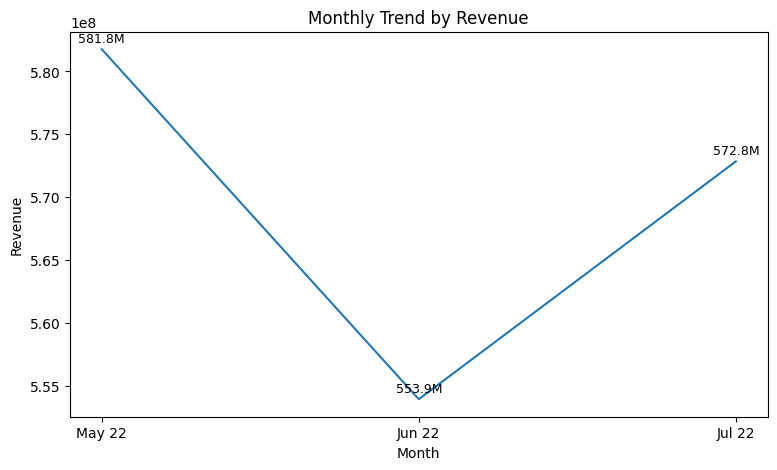

**7. Revenue realized per hotel type**

```
property_name
Atliq Seasons     66086735
Atliq Grands     211462134
Atliq Bay        259996918
Atliq Blu        260851922
Atliq City       285798439
Atliq Palace     304081863
Atliq Exotica    320258588
Name: revenue_realized, dtype: int64
```

```
Index(['Atliq Exotica', 'Atliq Palace', 'Atliq City', 'Atliq Blu', 'Atliq Bay',
       'Atliq Grands', 'Atliq Seasons'],
      dtype='object', name='property_name')
```

### Top Hotels by Revenue

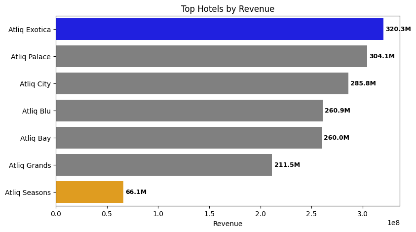

**8. Average rating per city**

```
city
Delhi        3.78
Hyderabad    3.66
Mumbai       3.65
Bangalore    3.41
Name: ratings_given, dtype: float64
```

```
Index(['Delhi', 'Hyderabad', 'Mumbai', 'Bangalore'], dtype='object', name='city')
```

### Avg Rating per City

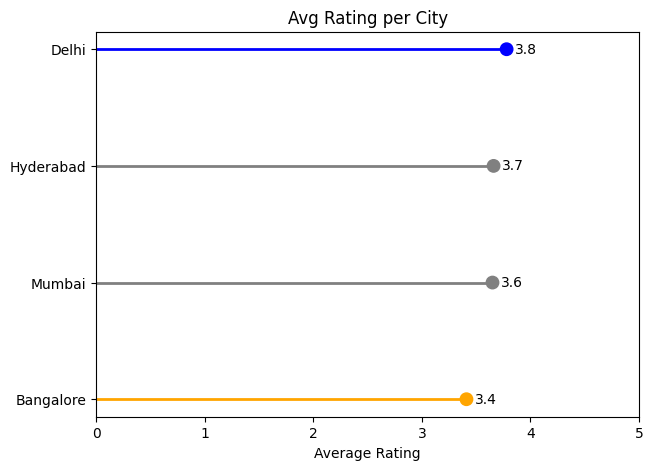

### Revenue realized per Booking Platform

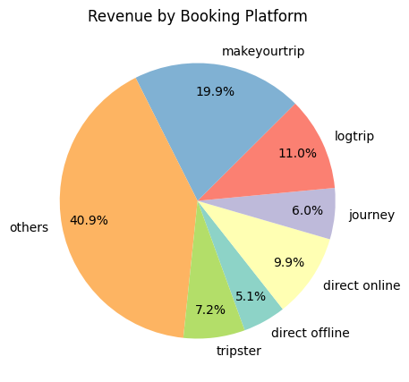

### Revenue by City and Booking Platform

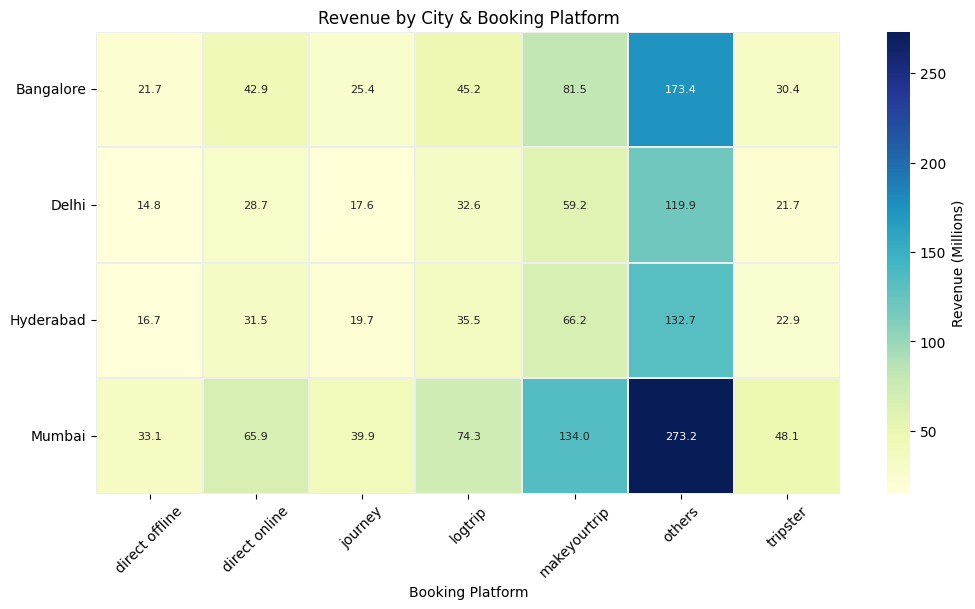

### Revenue: Weekday vs Weekend

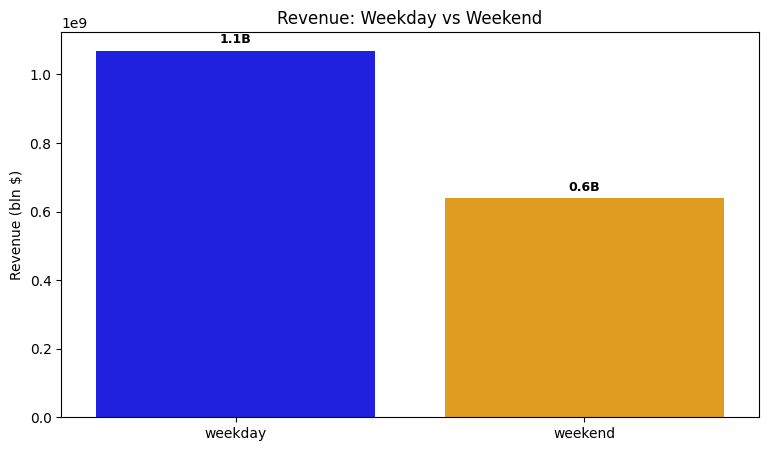

**Finding Revenue by Room Category**

**Merging df_bookings and df_rooms**

|  | booking_id | property_id | booking_date | check_in_date | checkout_date | no_guests | room_category | booking_platform | ratings_given | booking_status | revenue_generated | revenue_realized |
| --- | --- | --- | --- | --- | --- | --- | --- | --- | --- | --- | --- | --- |
| 1 | May012216558RT12 | 16558 | 2022-04-30 | 2022-05-01 | 2022-05-02 | 2.0 | RT1 | others | NaN | Cancelled | 9100 | 3640 |
| 4 | May012216558RT15 | 16558 | 2022-04-27 | 2022-05-01 | 2022-05-02 | 4.0 | RT1 | direct online | 5.0 | Checked Out | 10920 | 10920 |
| 5 | May012216558RT16 | 16558 | 2022-05-01 | 2022-05-01 | 2022-05-03 | 2.0 | RT1 | others | 4.0 | Checked Out | 9100 | 9100 |
| 6 | May012216558RT17 | 16558 | 2022-04-28 | 2022-05-01 | 2022-05-06 | 2.0 | RT1 | others | NaN | Cancelled | 9100 | 3640 |
| 7 | May012216558RT18 | 16558 | 2022-04-26 | 2022-05-01 | 2022-05-03 | 2.0 | RT1 | logtrip | NaN | No Show | 9100 | 9100 |

|  | room_id | room_class |
| --- | --- | --- |
| 0 | RT1 | Standard |
| 1 | RT2 | Elite |
| 2 | RT3 | Premium |
| 3 | RT4 | Presidential |

|  | booking_id | property_id | booking_date | check_in_date | checkout_date | no_guests | room_category | booking_platform | ratings_given | booking_status | revenue_generated | revenue_realized | room_id | room_class |
| --- | --- | --- | --- | --- | --- | --- | --- | --- | --- | --- | --- | --- | --- | --- |
| 0 | May012216558RT12 | 16558 | 2022-04-30 | 2022-05-01 | 2022-05-02 | 2.0 | RT1 | others | NaN | Cancelled | 9100 | 3640 | RT1 | Standard |
| 1 | May012216558RT15 | 16558 | 2022-04-27 | 2022-05-01 | 2022-05-02 | 4.0 | RT1 | direct online | 5.0 | Checked Out | 10920 | 10920 | RT1 | Standard |
| 2 | May012216558RT16 | 16558 | 2022-05-01 | 2022-05-01 | 2022-05-03 | 2.0 | RT1 | others | 4.0 | Checked Out | 9100 | 9100 | RT1 | Standard |
| 3 | May012216558RT17 | 16558 | 2022-04-28 | 2022-05-01 | 2022-05-06 | 2.0 | RT1 | others | NaN | Cancelled | 9100 | 3640 | RT1 | Standard |
| 4 | May012216558RT18 | 16558 | 2022-04-26 | 2022-05-01 | 2022-05-03 | 2.0 | RT1 | logtrip | NaN | No Show | 9100 | 9100 | RT1 | Standard |

|  | booking_id | property_id | booking_date | check_in_date | checkout_date | no_guests | room_category | booking_platform | ratings_given | booking_status | revenue_generated | revenue_realized | room_class |
| --- | --- | --- | --- | --- | --- | --- | --- | --- | --- | --- | --- | --- | --- |
| 0 | May012216558RT12 | 16558 | 2022-04-30 | 2022-05-01 | 2022-05-02 | 2.0 | RT1 | others | NaN | Cancelled | 9100 | 3640 | Standard |
| 1 | May012216558RT15 | 16558 | 2022-04-27 | 2022-05-01 | 2022-05-02 | 4.0 | RT1 | direct online | 5.0 | Checked Out | 10920 | 10920 | Standard |
| 2 | May012216558RT16 | 16558 | 2022-05-01 | 2022-05-01 | 2022-05-03 | 2.0 | RT1 | others | 4.0 | Checked Out | 9100 | 9100 | Standard |
| 3 | May012216558RT17 | 16558 | 2022-04-28 | 2022-05-01 | 2022-05-06 | 2.0 | RT1 | others | NaN | Cancelled | 9100 | 3640 | Standard |
| 4 | May012216558RT18 | 16558 | 2022-04-26 | 2022-05-01 | 2022-05-03 | 2.0 | RT1 | logtrip | NaN | No Show | 9100 | 9100 | Standard |

### Revenue by Room Category

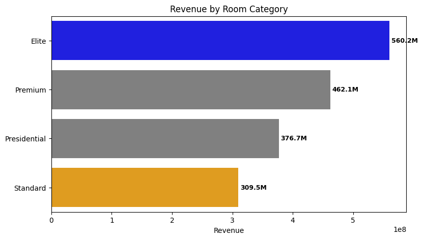